# Video Games Sales Dataset

```r
vid_sales1 <- read.csv("C:/Users/arzav/Downloads/vgsales.csv/vgsales.csv", header = TRUE, stringsAsFactors=FALSE)
vid_sales1
```

| Rank | Name | Platform | Year | Genre | Publisher | NA_Sales | EU_Sales | JP_Sales | Other_Sales | Global_Sales |
| --- | --- | --- | --- | --- | --- | --- | --- | --- | --- | --- |
| 1 | Wii Sports | Wii | 2006 | Sports | Nintendo | 41.49 | 29.02 | 3.77 | 8.46 | 82.74 |
| 2 | Super Mario Bros. | NES | 1985 | Platform | Nintendo | 29.08 | 3.58 | 6.81 | 0.77 | 40.24 |
| 3 | Mario Kart Wii | Wii | 2008 | Racing | Nintendo | 15.85 | 12.88 | 3.79 | 3.31 | 35.82 |
| 4 | Wii Sports Resort | Wii | 2009 | Sports | Nintendo | 15.75 | 11.01 | 3.28 | 2.96 | 33.00 |
| 5 | Pokemon Red/Pokemon Blue | GB | 1996 | Role-Playing | Nintendo | 11.27 | 8.89 | 10.22 | 1.00 | 31.37 |
| 6 | Tetris | GB | 1989 | Puzzle | Nintendo | 23.20 | 2.26 | 4.22 | 0.58 | 30.26 |
| 7 | New Super Mario Bros. | DS | 2006 | Platform | Nintendo | 11.38 | 9.23 | 6.50 | 2.90 | 30.01 |
| 8 | Wii Play | Wii | 2006 | Misc | Nintendo | 14.03 | 9.20 | 2.93 | 2.85 | 29.02 |
| 9 | New Super Mario Bros. Wii | Wii | 2009 | Platform | Nintendo | 14.59 | 7.06 | 4.70 | 2.26 | 28.62 |
| 10 | Duck Hunt | NES | 1984 | Shooter | Nintendo | 26.93 | 0.63 | 0.28 | 0.47 | 28.31 |

[output cut: 990 more lines]

The dataset contains 16,598 rows and 11 columns

```r
str(vid_sales1)
```

```
'data.frame':   16598 obs. of  11 variables:
 $ Rank        : int  1 2 3 4 5 6 7 8 9 10 ...
 $ Name        : chr  "Wii Sports" "Super Mario Bros." "Mario Kart Wii" "Wii Sports Resort" ...
 $ Platform    : chr  "Wii" "NES" "Wii" "Wii" ...
 $ Year        : chr  "2006" "1985" "2008" "2009" ...
 $ Genre       : chr  "Sports" "Platform" "Racing" "Sports" ...
 $ Publisher   : chr  "Nintendo" "Nintendo" "Nintendo" "Nintendo" ...
 $ NA_Sales    : num  41.5 29.1 15.8 15.8 11.3 ...
 $ EU_Sales    : num  29.02 3.58 12.88 11.01 8.89 ...
 $ JP_Sales    : num  3.77 6.81 3.79 3.28 10.22 ...
 $ Other_Sales : num  8.46 0.77 3.31 2.96 1 0.58 2.9 2.85 2.26 0.47 ...
 $ Global_Sales: num  82.7 40.2 35.8 33 31.4 ...
```

The dataset has 6 numeric variables and five categorical variables.

```r
summary(vid_sales1)
```

```
      Rank           Name             Platform             Year              Genre
 Min.   :    1   Length:16598       Length:16598       Length:16598       Length:16598
 1st Qu.: 4151   Class :character   Class :character   Class :character   Class :character
 Median : 8300   Mode  :character   Mode  :character   Mode  :character   Mode  :character
 Mean   : 8301
 3rd Qu.:12450
 Max.   :16600
  Publisher            NA_Sales          EU_Sales          JP_Sales         Other_Sales
 Length:16598       Min.   : 0.0000   Min.   : 0.0000   Min.   : 0.00000   Min.   : 0.00000
 Class :character   1st Qu.: 0.0000   1st Qu.: 0.0000   1st Qu.: 0.00000   1st Qu.: 0.00000
 Mode  :character   Median : 0.0800   Median : 0.0200   Median : 0.00000   Median : 0.01000
                    Mean   : 0.2647   Mean   : 0.1467   Mean   : 0.07778   Mean   : 0.04806
                    3rd Qu.: 0.2400   3rd Qu.: 0.1100   3rd Qu.: 0.04000   3rd Qu.: 0.04000
                    Max.   :41.4900   Max.   :29.0200   Max.   :10.22000   Max.   :10.57000
  Global_Sales
 Min.   : 0.0100
 1st Qu.: 0.0600
 Median : 0.1700
 Mean   : 0.5374
 3rd Qu.: 0.4700
 Max.   :82.7400
```

Here above we see the summary of the data

```r
colSums(is.na(vid_sales1))
```

```
        Rank         Name     Platform         Year        Genre    Publisher     NA_Sales     EU_Sales
           0            0            0            0            0            0            0            0
    JP_Sales  Other_Sales Global_Sales
           0            0            0
```

```r
sum(is.na(vid_sales1$Year))
```

```
[1] 0
```

```r
vid_sales1$Rank <- NULL
vid_sales1$Name <- NULL
```

The rank and name are not necessory for the analysis so we remove them for the model

```r
vid_sales1$Year <- as.numeric(vid_sales1$Year)
```

```
Warning: NAs introduced by coercion
```

We see here that Year variables has some missing values so we are getting the warning

```r
sum(is.na(vid_sales1$Year))
```

```
[1] 271
```

Year has 271 missing values

```r
colSums(is.na(vid_sales1))
```

```
    Platform         Year        Genre    Publisher     NA_Sales     EU_Sales     JP_Sales  Other_Sales
           0          271            0            0            0            0            0            0
Global_Sales
           0
```

```r
mean_year <- mean(vid_sales1$Year, na.rm = TRUE)
vid_sales1$Year[is.na(vid_sales1$Year)] <- mean_year
```

Here we replace the missing values with the mean

```r
sum(is.na(vid_sales1$Year))
```

```
[1] 0
```

```r
vid_sales1$Year <- as.numeric(vid_sales1$Year)
```

Here then we convert Year variable from char to numeric

```r
vid_sales1$Platform <- as.factor(vid_sales1$Platform)
vid_sales1$Genre <- as.factor(vid_sales1$Genre)
vid_sales1$Publisher <- as.factor(vid_sales1$Publisher)
```

We convert the categorical variables to factors

```r
str(vid_sales1)
```

```
'data.frame':   16598 obs. of  9 variables:
 $ Platform    : Factor w/ 31 levels "2600","3DO","3DS",..: 26 12 26 26 6 6 5 26 26 12 ...
 $ Year        : num  2006 1985 2008 2009 1996 ...
 $ Genre       : Factor w/ 12 levels "Action","Adventure",..: 11 5 7 11 8 6 5 4 5 9 ...
 $ Publisher   : Factor w/ 579 levels "10TACLE Studios",..: 369 369 369 369 369 369 369 369 369 369 ...
 $ NA_Sales    : num  41.5 29.1 15.8 15.8 11.3 ...
 $ EU_Sales    : num  29.02 3.58 12.88 11.01 8.89 ...
 $ JP_Sales    : num  3.77 6.81 3.79 3.28 10.22 ...
 $ Other_Sales : num  8.46 0.77 3.31 2.96 1 0.58 2.9 2.85 2.26 0.47 ...
 $ Global_Sales: num  82.7 40.2 35.8 33 31.4 ...
```

#EXPLORARTORY DATA ANALYSIS

```r
#library(tidyverse)
correlation_matrix <- cor(vid_sales1[, c('NA_Sales', 'EU_Sales', 'JP_Sales', 'Other_Sales', 'Global_Sales')])
correlation_matrix
```

```
              NA_Sales  EU_Sales  JP_Sales Other_Sales Global_Sales
NA_Sales     1.0000000 0.7677267 0.4497874   0.6347373    0.9410474
EU_Sales     0.7677267 1.0000000 0.4355845   0.7263849    0.9028358
JP_Sales     0.4497874 0.4355845 1.0000000   0.2901862    0.6118155
Other_Sales  0.6347373 0.7263849 0.2901862   1.0000000    0.7483308
Global_Sales 0.9410474 0.9028358 0.6118155   0.7483308    1.0000000
```

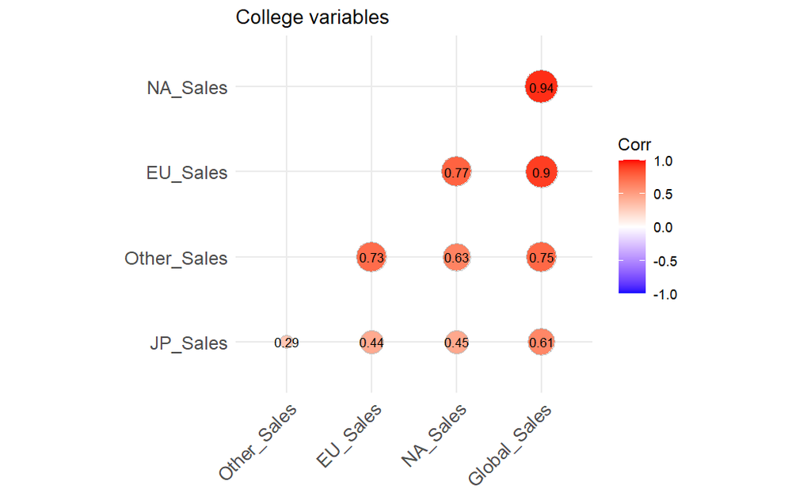

```r
library(ggcorrplot)
ggcorrplot(correlation_matrix, hc.order = TRUE, type = "lower", lab = TRUE, lab_size = 3, method="circle", colors = c("blue", "white", "red"), outline.color = "gray", show.legend = TRUE, show.diag = FALSE, title="College variables")
```

We use the correlation plot to find the relationship between numeric variables

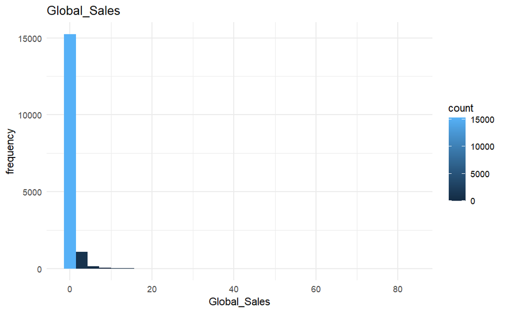

```r
library(ggplot2)
ggplot(vid_sales1, aes(x=Global_Sales, fill=after_stat(count)))+geom_histogram()+ggtitle("Global_Sales")+ylab("frequency")+xlab("Global_Sales")+theme(plot.title=element_text(hjust=0.5))+theme_minimal()
```

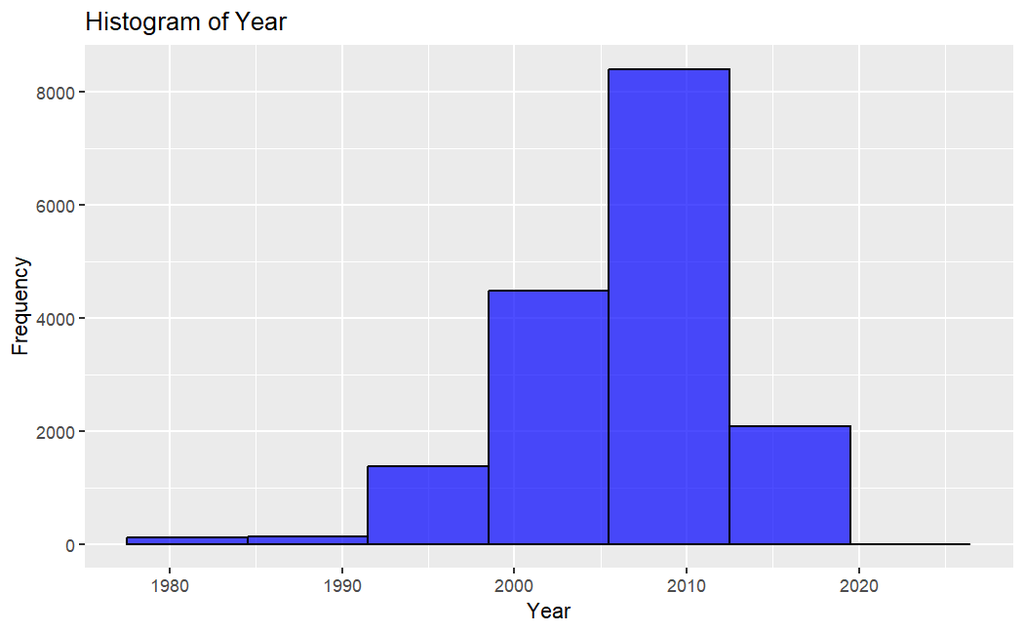

```r
library(ggplot2)


ggplot(vid_sales1, aes(x = Year)) +
  geom_histogram(binwidth = 7, fill = "blue", color = "black", alpha = 0.7) +
  labs(title = "Histogram of Year",
       x = "Year",
       y = "Frequency")
```

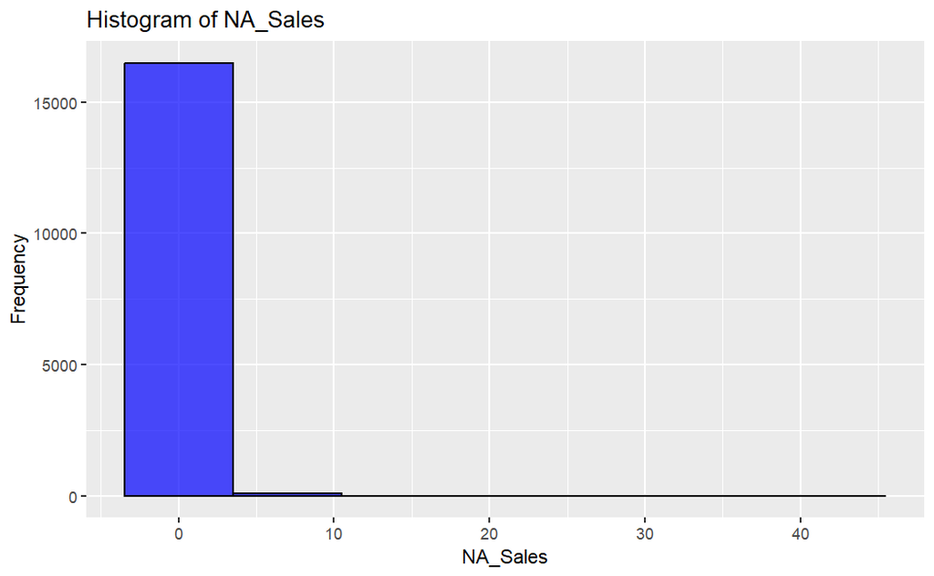

```r
library(ggplot2)

# Replace 'NumericVariable' with your actual numerical variable
ggplot(vid_sales1, aes(x = NA_Sales)) +
  geom_histogram(binwidth = 7, fill = "blue", color = "black", alpha = 0.7) +
  labs(title = "Histogram of NA_Sales",
       x = "NA_Sales",
       y = "Frequency")
```

```r
NA
NA
```

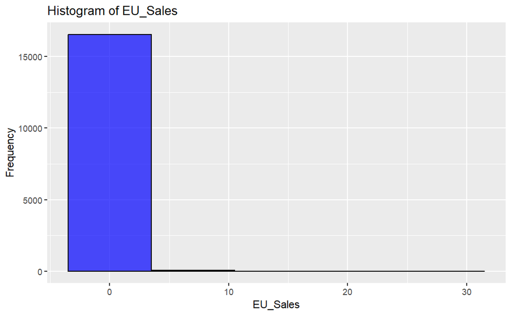

```r
ggplot(vid_sales1, aes(x = EU_Sales)) +
  geom_histogram(binwidth = 7, fill = "blue", color = "black", alpha = 0.7) +
  labs(title = "Histogram of EU_Sales",
       x = "EU_Sales",
       y = "Frequency")
```

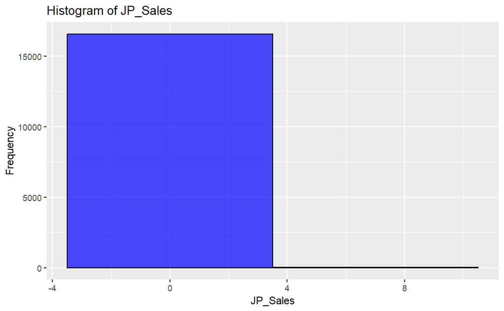

```r
ggplot(vid_sales1, aes(x = JP_Sales)) +
  geom_histogram(binwidth = 7, fill = "blue", color = "black", alpha = 0.7) +
  labs(title = "Histogram of JP_Sales",
       x = "JP_Sales",
       y = "Frequency")
```

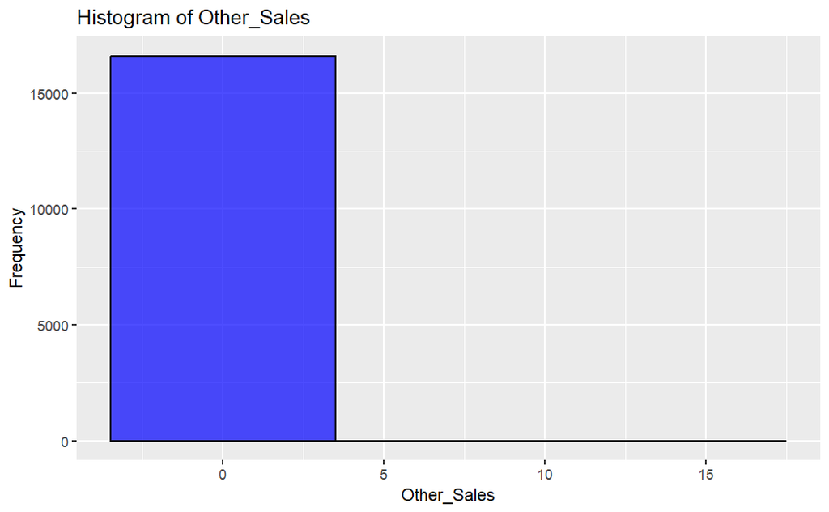

```r
ggplot(vid_sales1, aes(x = Other_Sales)) +
  geom_histogram(binwidth = 7, fill = "blue", color = "black", alpha = 0.7) +
  labs(title = "Histogram of Other_Sales",
       x = "Other_Sales",
       y = "Frequency")
```

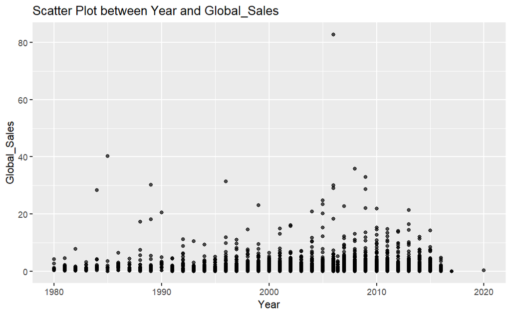

```r
ggplot(vid_sales1, aes(x = Year, y = Global_Sales)) +
  geom_point(alpha = 0.7) +
  labs(title = "Scatter Plot between Year and Global_Sales",
       x = "Year",
       y = "Global_Sales")
```

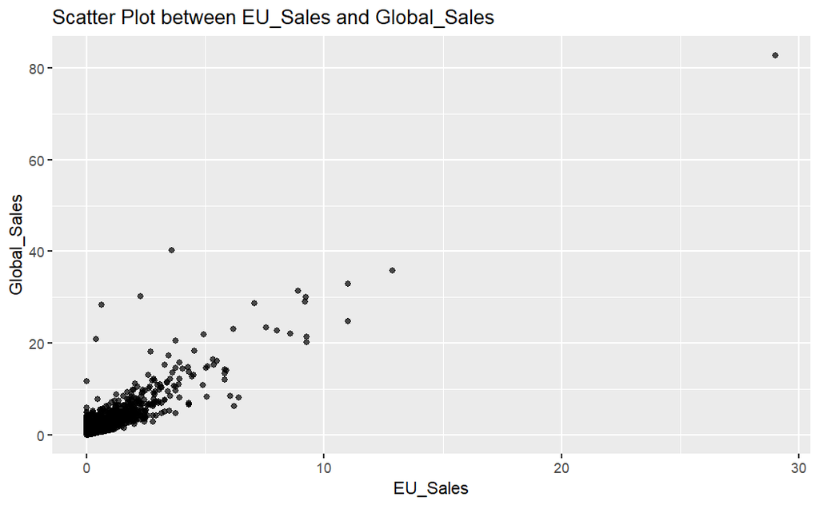

```r
# Replace 'NumericVariable1' with your actual numerical variable
ggplot(vid_sales1, aes(x = EU_Sales, y = Global_Sales)) +
  geom_point(alpha = 0.7) +
  labs(title = "Scatter Plot between EU_Sales and Global_Sales",
       x = "EU_Sales",
       y = "Global_Sales")
```

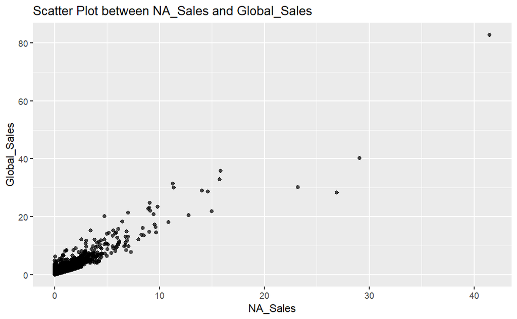

```r
ggplot(vid_sales1, aes(x = NA_Sales, y = Global_Sales)) +
  geom_point(alpha = 0.7) +
  labs(title = "Scatter Plot between NA_Sales and Global_Sales",
       x = "NA_Sales",
       y = "Global_Sales")
```

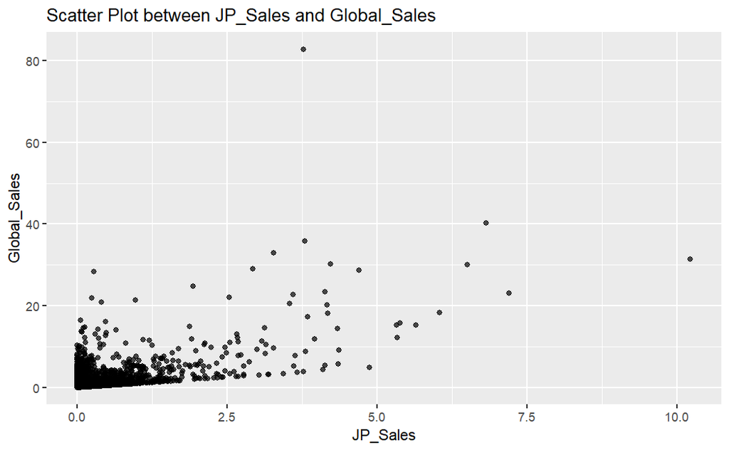

```r
ggplot(vid_sales1, aes(x = JP_Sales, y = Global_Sales)) +
  geom_point(alpha = 0.7) +
  labs(title = "Scatter Plot between JP_Sales and Global_Sales",
       x = "JP_Sales",
       y = "Global_Sales")
```

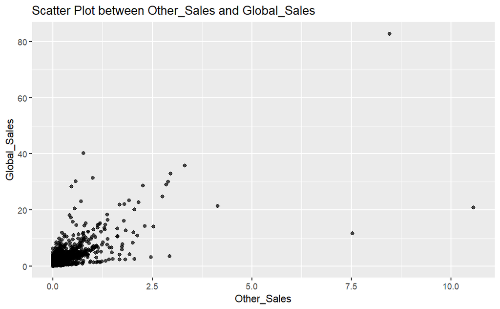

```r
ggplot(vid_sales1, aes(x = Other_Sales, y = Global_Sales)) +
  geom_point(alpha = 0.7) +
  labs(title = "Scatter Plot between Other_Sales and Global_Sales",
       x = "Other_Sales",
       y = "Global_Sales")
```

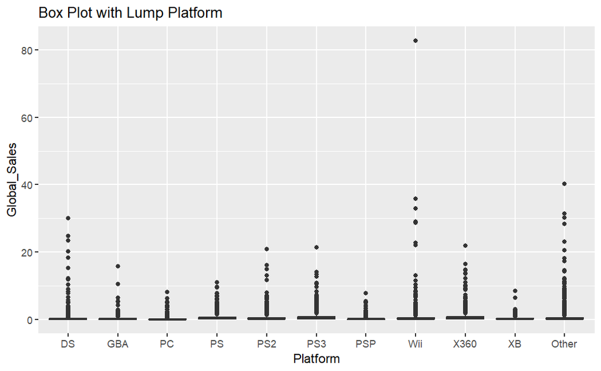

```r
library(dplyr)
library(ggplot2)
library(forcats)
vid_sales1 %>%
  mutate(Platform = fct_lump(Platform, n = 10)) %>%
  ggplot(aes(x = Platform, y = Global_Sales)) +
  geom_boxplot() +
  labs(title = "Box Plot with Lump Platform",
       x = "Platform",
       y = "Global_Sales")
```

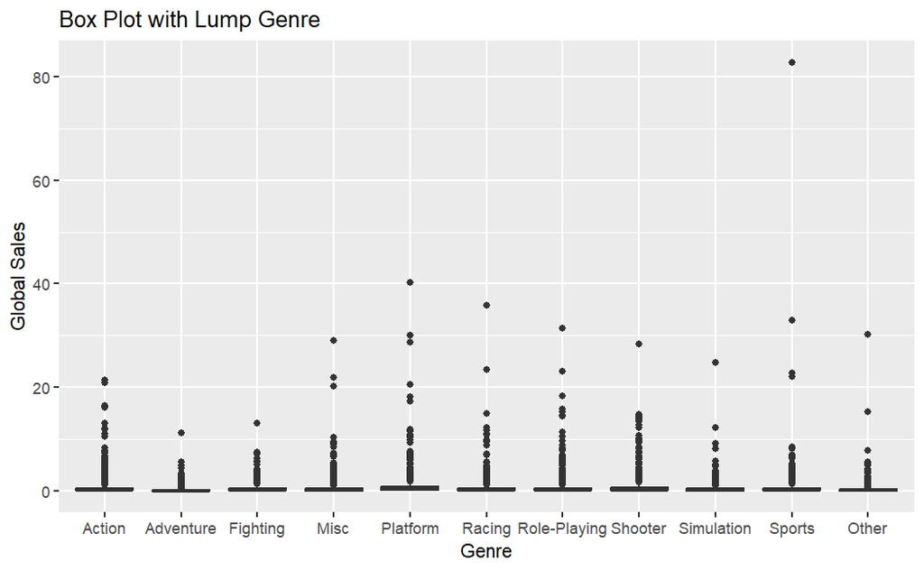

```r
vid_sales1 %>%
  mutate(Genre = fct_lump(Genre, n = 10)) %>%
  ggplot(aes(x = Genre, y = Global_Sales)) +
  geom_boxplot() +
  labs(title = "Box Plot with Lump Genre",
       x = "Genre",
       y = "Global Sales")
```

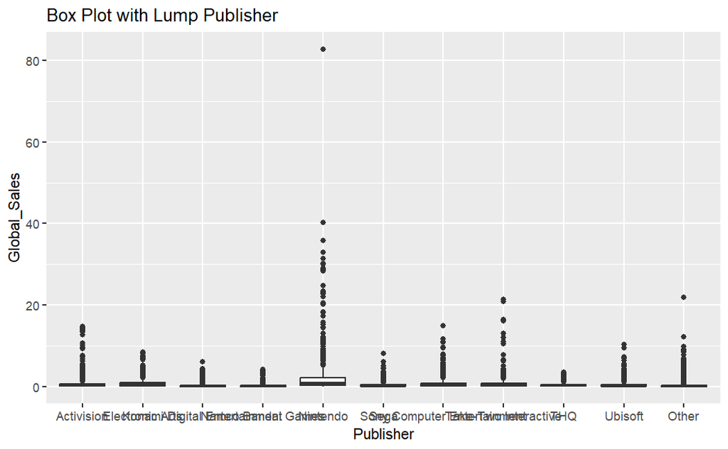

```r
vid_sales1 %>%
  mutate(Publisher = fct_lump(Publisher, n = 10)) %>%
  ggplot(aes(x = Publisher, y = Global_Sales)) +
  geom_boxplot() +
  labs(title = "Box Plot with Lump Publisher",
       x = "Publisher",
       y = "Global_Sales")
```

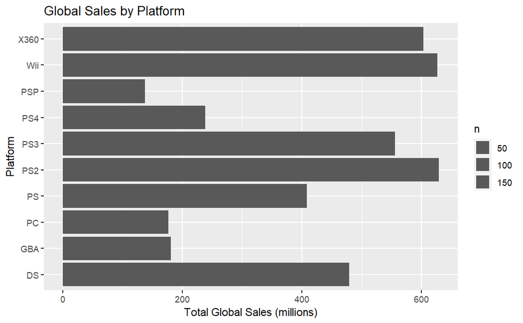

```r
library(dplyr)
library(stats)
library(base)
top_platforms <- vid_sales1 %>%
  group_by(Platform) %>%
  summarize(total_sales = sum(Global_Sales)) %>%
  arrange(desc(total_sales)) %>%
  top_n(10)  # Adjust the number of top platforms to show
# Create a bar plot
ggplot(vid_sales1 %>% filter(Platform %in% top_platforms$Platform), aes(x = Platform, y = Global_Sales)) +
  geom_bar(stat = "sum") +
  coord_flip() +
  labs(title = "Global Sales by Platform",
       x = "Platform",
       y = "Total Global Sales (millions)")
```

```r
NA
NA
```

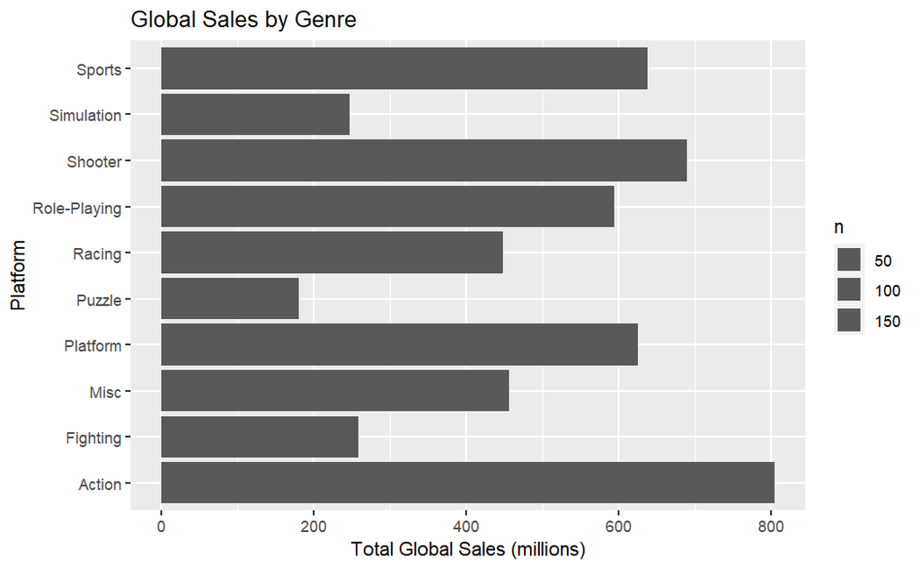

```r
top_platforms <- vid_sales1 %>%
  group_by(Genre) %>%
  summarize(total_sales = sum(Global_Sales)) %>%
  arrange(desc(total_sales)) %>%
  top_n(10)  # Adjust the number of top platforms to show
# Create a bar plot
ggplot(vid_sales1 %>% filter(Genre %in% top_platforms$Genre), aes(x = Genre, y = Global_Sales)) +
  geom_bar(stat = "sum") +
  coord_flip() +
  labs(title = "Global Sales by Genre",
       x = "Platform",
       y = "Total Global Sales (millions)")
```

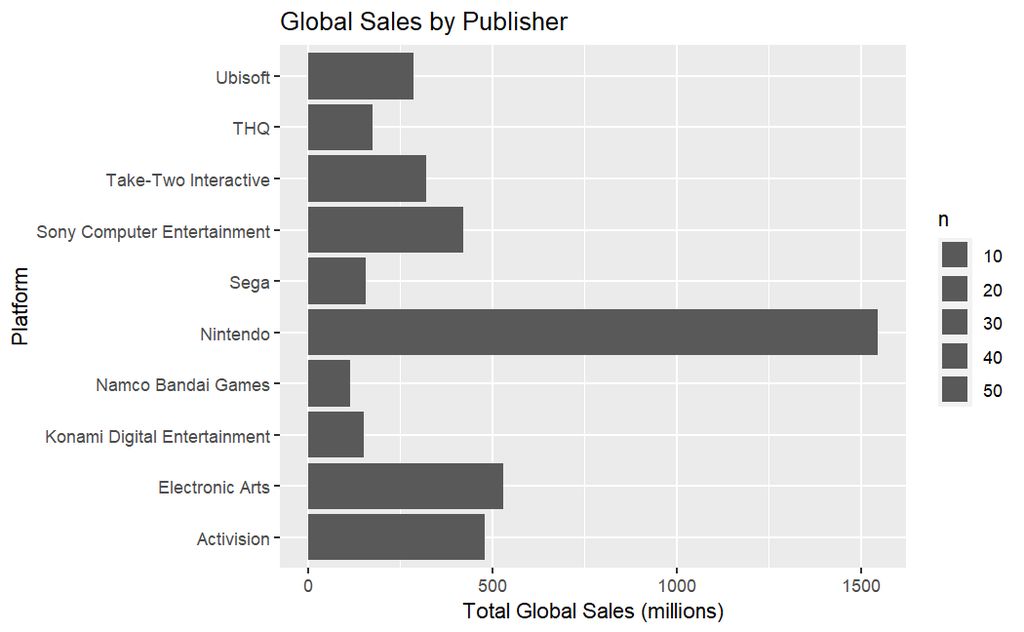

```r
top_platforms <- vid_sales1 %>%
  group_by(Publisher) %>%
  summarize(total_sales = sum(Global_Sales)) %>%
  arrange(desc(total_sales)) %>%
  top_n(10)  # Adjust the number of top platforms to show
# Create a bar plot
ggplot(vid_sales1 %>% filter(Publisher %in% top_platforms$Publisher), aes(x = Publisher, y = Global_Sales)) +
  geom_bar(stat = "sum") +
  coord_flip() +
  labs(title = "Global Sales by Publisher",
       x = "Platform",
       y = "Total Global Sales (millions)")
```

#SPLITTING AND TRAINING THE DATA

Before we can develop the model, we must divide the data into train and test datasets. We will use the train dataset to develop a linear regression model, and the test dataset as a comparison to check if the model becomes overfit or cannot predict fresh data. We will utilize 80% of the data as training data and the remaining 20% as testing data.

```r
set.seed(1)
train.index=createDataPartition(vid_sales1$Global_Sales, p=0.8, list = FALSE)
vid_train<-vid_sales1[train.index, ]
vid_test <-vid_sales1[-train.index, ]
vid_train_labels = vid_train[train.index, 8]
vid_test_labels = vid_test[-train.index,8]
```

```r
vid_train
```

|  | Platform | Year | Genre | Publisher | NA_Sales | EU_Sales | JP_Sales | Other_Sales | Global_Sales |
| --- | --- | --- | --- | --- | --- | --- | --- | --- | --- |
| 3 | Wii | 2008.000 | Racing | Nintendo | 15.85 | 12.88 | 3.79 | 3.31 | 35.82 |
| 4 | Wii | 2009.000 | Sports | Nintendo | 15.75 | 11.01 | 3.28 | 2.96 | 33.00 |
| 5 | GB | 1996.000 | Role-Playing | Nintendo | 11.27 | 8.89 | 10.22 | 1.00 | 31.37 |
| 6 | GB | 1989.000 | Puzzle | Nintendo | 23.20 | 2.26 | 4.22 | 0.58 | 30.26 |
| 8 | Wii | 2006.000 | Misc | Nintendo | 14.03 | 9.20 | 2.93 | 2.85 | 29.02 |
| 9 | Wii | 2009.000 | Platform | Nintendo | 14.59 | 7.06 | 4.70 | 2.26 | 28.62 |
| 10 | NES | 1984.000 | Shooter | Nintendo | 26.93 | 0.63 | 0.28 | 0.47 | 28.31 |
| 12 | DS | 2005.000 | Racing | Nintendo | 9.81 | 7.57 | 4.13 | 1.92 | 23.42 |
| 13 | GB | 1999.000 | Role-Playing | Nintendo | 9.00 | 6.18 | 7.20 | 0.71 | 23.10 |
| 14 | Wii | 2007.000 | Sports | Nintendo | 8.94 | 8.03 | 3.60 | 2.15 | 22.72 |

[output cut: 990 more lines]

```r
NA
```

```r
vid_test
```

|  | Platform | Year | Genre | Publisher | NA_Sales | EU_Sales | JP_Sales | Other_Sales | Global_Sales |
| --- | --- | --- | --- | --- | --- | --- | --- | --- | --- |
| 1 | Wii | 2006.000 | Sports | Nintendo | 41.49 | 29.02 | 3.77 | 8.46 | 82.74 |
| 2 | NES | 1985.000 | Platform | Nintendo | 29.08 | 3.58 | 6.81 | 0.77 | 40.24 |
| 7 | DS | 2006.000 | Platform | Nintendo | 11.38 | 9.23 | 6.50 | 2.90 | 30.01 |
| 11 | DS | 2005.000 | Simulation | Nintendo | 9.07 | 11.00 | 1.93 | 2.75 | 24.76 |
| 15 | Wii | 2009.000 | Sports | Nintendo | 9.09 | 8.59 | 2.53 | 1.79 | 22.00 |
| 17 | PS3 | 2013.000 | Action | Take-Two Interactive | 7.01 | 9.27 | 0.97 | 4.14 | 21.40 |
| 23 | NES | 1988.000 | Platform | Nintendo | 9.54 | 3.44 | 3.84 | 0.46 | 17.28 |
| 28 | DS | 2005.000 | Puzzle | Nintendo | 3.44 | 5.36 | 5.32 | 1.18 | 15.30 |
| 43 | 3DS | 2011.000 | Racing | Nintendo | 4.74 | 3.91 | 2.67 | 0.89 | 12.21 |
| 54 | 3DS | 2011.000 | Platform | Nintendo | 4.89 | 2.99 | 2.13 | 0.78 | 10.79 |

[output cut: 990 more lines]

```r
NA
```

#Linear Regression

```r
set.seed(1)

train.control =trainControl(method = "cv", number = 5)
linear_model<-train(Global_Sales~.,data = vid_train, method =
"lm",trControl = train.control)
linear_model
```

```
Linear Regression

13280 samples
    8 predictor

No pre-processing
Resampling: Cross-Validated (5 fold)
Summary of sample sizes: 10625, 10623, 10623, 10624, 10625
Resampling results:

  RMSE         Rsquared   MAE
  0.005299251  0.9999857  0.003145773

Tuning parameter 'intercept' was held constant at a value of TRUE
```

```r
model_lm <- lm(Global_Sales ~ ., data = vid_train)
summary(model_lm)
```

```
Call:
lm(formula = Global_Sales ~ ., data = vid_train)

Residuals:
       Min         1Q     Median         3Q        Max
-0.0201660 -0.0007262 -0.0001309  0.0003349  0.0200350

Coefficients:
                                                  Estimate Std. Error   t value Pr(>|t|)
(Intercept)                                      5.942e-02  4.216e-02     1.409   0.1588
Platform3DO                                     -2.396e-04  4.130e-03    -0.058   0.9537
Platform3DS                                      1.875e-04  8.896e-04     0.211   0.8331
PlatformDC                                       6.045e-04  1.120e-03     0.540   0.5894
PlatformDS                                       2.796e-04  8.006e-04     0.349   0.7269
PlatformGB                                      -2.565e-04  9.310e-04    -0.276   0.7829
PlatformGBA                                      5.635e-04  7.680e-04     0.734   0.4632
PlatformGC                                       5.846e-04  7.844e-04     0.745   0.4561
PlatformGEN                                      4.249e-04  1.341e-03     0.317   0.7514
PlatformGG                                      -1.347e-04  5.297e-03    -0.025   0.9797
PlatformN64                                      3.605e-04  7.910e-04     0.456   0.6486
PlatformNES                                     -5.629e-04  9.242e-04    -0.609   0.5425
PlatformNG                                      -1.697e-04  2.468e-03    -0.069   0.9452
PlatformPC                                       7.939e-04  8.253e-04     0.962   0.3361
PlatformPCFX                                    -9.229e-05  7.467e-03    -0.012   0.9901
PlatformPS                                      -3.209e-04  7.311e-04    -0.439   0.6607
PlatformPS2                                     -1.692e-04  7.630e-04    -0.222   0.8245
PlatformPS3                                      2.550e-04  8.368e-04     0.305   0.7606
PlatformPS4                                      1.722e-04  9.317e-04     0.185   0.8534
PlatformPSP                                     -2.046e-05  8.137e-04    -0.025   0.9799
PlatformPSV                                      3.440e-05  9.126e-04     0.038   0.9699
PlatformSAT                                     -1.453e-04  8.485e-04    -0.171   0.8641
PlatformSCD                                      1.594e-03  2.260e-03     0.705   0.4805
PlatformSNES                                    -2.626e-04  8.079e-04    -0.325   0.7452
PlatformTG16                                    -1.724e-04  5.334e-03    -0.032   0.9742
PlatformWii                                      4.004e-04  8.140e-04     0.492   0.6228
PlatformWiiU                                     4.176e-04  9.870e-04     0.423   0.6722
PlatformWS                                      -7.087e-05  2.279e-03    -0.031   0.9752
PlatformX360                                     5.291e-04  8.250e-04     0.641   0.5213
PlatformXB                                       6.940e-04  7.740e-04     0.897   0.3700
PlatformXOne                                     3.205e-05  9.725e-04     0.033   0.9737
```

[output cut: 161 more lines]

```
PublisherFlight-Plan                             2.279e-04  6.062e-03     0.038   0.9700
PublisherFocus Home Interactive                 -1.946e-04  3.129e-03    -0.062   0.9504
PublisherFocus Multimedia                       -6.224e-04  4.798e-03    -0.130   0.8968
Publisherfonfun                                  2.779e-04  6.067e-03     0.046   0.9635
PublisherForeign Media Games                    -5.777e-05  3.623e-03    -0.016   0.9873
PublisherFortyfive                              -6.164e-04  6.121e-03    -0.101   0.9198
PublisherFox Interactive                         2.290e-04  3.719e-03     0.062   0.9509
PublisherFrom Software                          -1.951e-05  3.504e-03    -0.006   0.9956
 [ reached getOption("max.print") -- omitted 386 rows ]
---
Signif. codes:  0 ‘***’ 0.001 ‘**’ 0.01 ‘*’ 0.05 ‘.’ 0.1 ‘ ’ 1

Residual standard error: 0.005246 on 12694 degrees of freedom
Multiple R-squared:      1, Adjusted R-squared:      1
F-statistic: 1.622e+06 on 585 and 12694 DF,  p-value: < 2.2e-16
```

```r
vid_pred<-predict(linear_model, vid_test)
vid_pred
```

[output not shown]

[output cut: 170 more lines]

[output not shown]

```r
RMSE(vid_pred,vid_test$Global_Sales)
```

```
[1] 0.00528809
```

#LASSO

```r
set.seed(1)
lasso <- train(
Global_Sales ~., data = vid_train, method = "glmnet",
trControl = trainControl("cv", number = 10),
preProcess=c("knnImpute","nzv"),
tuneGrid = expand.grid(alpha = 1, lambda = 10^seq(3, -3, length = 100)))
```

```r
lasso
```

```
glmnet

13280 samples
    8 predictor

Pre-processing: nearest neighbor imputation (27), centered (27), scaled (27), remove (597)
Resampling: Cross-Validated (10 fold)
Summary of sample sizes: 11952, 11952, 11953, 11950, 11953, 11951, ...
Resampling results across tuning parameters:

  lambda        RMSE        Rsquared   MAE
  1.000000e-03  0.04188508  0.9998206  0.01696615
  1.149757e-03  0.04188508  0.9998206  0.01696615
  1.321941e-03  0.04188508  0.9998206  0.01696615
  1.519911e-03  0.04188508  0.9998206  0.01696615
  1.747528e-03  0.04188508  0.9998206  0.01696615
  2.009233e-03  0.04188508  0.9998206  0.01696615
  2.310130e-03  0.04188508  0.9998206  0.01696615
  2.656088e-03  0.04188508  0.9998206  0.01696615
  3.053856e-03  0.04188508  0.9998206  0.01696615
  3.511192e-03  0.04188508  0.9998206  0.01696615
  4.037017e-03  0.04188508  0.9998206  0.01696615
  4.641589e-03  0.04188508  0.9998206  0.01696615
  5.336699e-03  0.04188508  0.9998206  0.01696615
  6.135907e-03  0.04188508  0.9998206  0.01696615
  7.054802e-03  0.04188508  0.9998206  0.01696615
  8.111308e-03  0.04188508  0.9998206  0.01696615
  9.326033e-03  0.04188508  0.9998206  0.01696615
  1.072267e-02  0.04188508  0.9998206  0.01696615
  1.232847e-02  0.04188508  0.9998206  0.01696615
  1.417474e-02  0.04188508  0.9998206  0.01696615
  1.629751e-02  0.04188508  0.9998206  0.01696615
  1.873817e-02  0.04188508  0.9998206  0.01696615
  2.154435e-02  0.04188508  0.9998206  0.01696615
  2.477076e-02  0.04188508  0.9998206  0.01696615
  2.848036e-02  0.04188508  0.9998206  0.01696615
  3.274549e-02  0.04342487  0.9998123  0.01756906
  3.764936e-02  0.04939119  0.9997668  0.01995057
  4.328761e-02  0.05670741  0.9996935  0.02285385
  4.977024e-02  0.06511262  0.9995961  0.02620409
```

[output cut: 60 more lines]

```
  2.477076e+02  1.38864714        NaN  0.58439619
  2.848036e+02  1.38864714        NaN  0.58439619
  3.274549e+02  1.38864714        NaN  0.58439619
  3.764936e+02  1.38864714        NaN  0.58439619
  4.328761e+02  1.38864714        NaN  0.58439619
  4.977024e+02  1.38864714        NaN  0.58439619
  5.722368e+02  1.38864714        NaN  0.58439619
  6.579332e+02  1.38864714        NaN  0.58439619
  7.564633e+02  1.38864714        NaN  0.58439619
  8.697490e+02  1.38864714        NaN  0.58439619
  1.000000e+03  1.38864714        NaN  0.58439619

Tuning parameter 'alpha' was held constant at a value of 1
RMSE was used to select the optimal model using the smallest value.
The final values used for the model were alpha = 1 and lambda = 0.02848036.
```